# Week 3 Homework: Titis in the Mist

Victoria Zdanowicz

9/23/2021

Prompt - Every Saturday morning, at the same time, a primatologist goes and sits in the forest to listen for titi monkey calls, counting the number of calls they hear in a 2 hour window from 5am to 7am. Based on previous knowledge, she believes that the mean number of calls she will hear in that time is exactly 15. Let X represent the appropriate Poisson random variable of the number of calls heard in each monitoring session.

# Challenge 1

> What is the probability that she will hear more than 8 calls during any given session?

This question requires the argument [lower = FALSE] to calculate the probability of more than 8 calls since it in the upper tail of the probability density function.

```r
x<- ppois(8, lambda=15, lower=FALSE)
x
```

```
## [1] 0.9625535
```

# Challenge 2

> What is the probability that she will hear no calls in a session?

Without the [lower = FALSE] argument, this command calculates the probability of zero or fewer calls in a session.

```r
x<- ppois(0, lambda=15)
x
```

```
## [1] 3.059023e-07
```

# Challenge 3

> What is the probability that she will hear exactly 3 calls in a session?

The function dpois() calculates the probability of a random variable, exact number of calls in this instance, that is available within a certain range.

```r
x<- dpois(3, lambda=15, log=FALSE) #if log = TRUE, probability is given as log
x
```

```
## [1] 0.0001720701
```

# Challenge 4

> Plot the relevant Poisson mass function over the values in range 0 ≤ x ≤ 30.

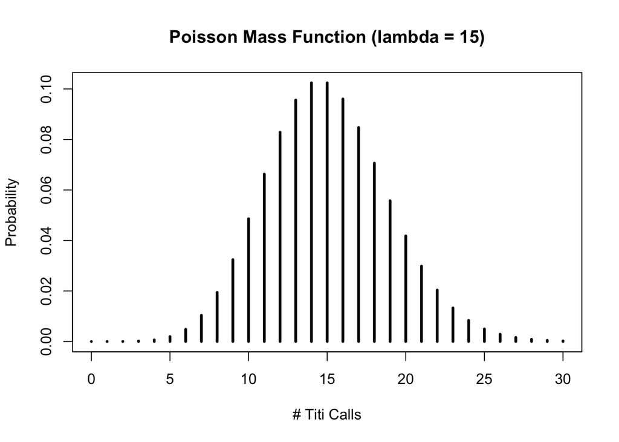

```r
z<-dpois(0:30, lambda = 15)
plot(0:30, dpois(0:30, lambda = 15),
     type='h',
     main='Poisson Mass Function (lambda = 15)',
     ylab='Probability',
     xlab ='# Titi Calls',
     lwd=3)
```

# Challenge 5

> Simulate 104 results from this distribution (i.e., 2 years of Saturday monitoring sessions). Plot the simulated results using hist() and use xlim() to set the horizontal limits to be from 0 to 30. How does your histogram compare to the shape of the probability mass function you plotted above?

The function rpois() is used for generating random numbers from a given Poisson’s distribution.

```r
y<-rpois(104,lambda=15)
y
```

```
##   [1] 17 17 17 18 17 17 15 19 12 15 15 21 10 24 16 13 15 14 14 18 14 14 13 16 23
##  [26] 13 16 16 12 19 18 20 16 12 13 14 14 12 12 18 24 14 18 12 18 13 15 12 19 23
##  [51] 12 17 12 17 24 11 16 10 14 18 24 13 11 10 18  8 18 18 17 20 11 14 17 14 12
##  [76] 12 18 14 13 17 22 12 17 25 15 18 10 11 15 16 14 18 19 12 14 17 14 23 23 13
## [101] 17 17 13 12
```

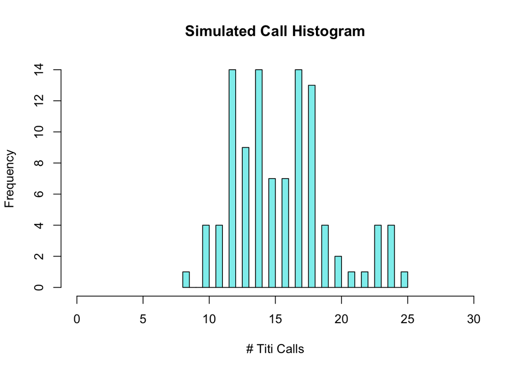

```r
hist(y,xlim=c(0,30),xlab="# Titi Calls",main="Simulated Call Histogram",breaks=30,col="darkslategray2")
```

Both histograms are similar in general shape/trend but the “Simulated Call Histogram” would likely appear more similar to the “Poisson Mass Function” as more results are added to the sample size.